# A Friendly Intro to R - BioData Club

Danielle Robinson & Lilly Winfree

May 26 2017

## Before we begin

- Download R - this is the binary containing R language stuff - it comes with a basic interface, but we won’t use it. You need to download this first so your computer will know what to do with R Studio.
  - https://cran.rstudio.com/
- Download R Studio - this is an interface that makes it easy to work with R.
  - https://www.rstudio.com/products/rstudio/download3/
- Go to our Github page:
  - https://github.com/BioData-Club/Friendly-Intro-to-R

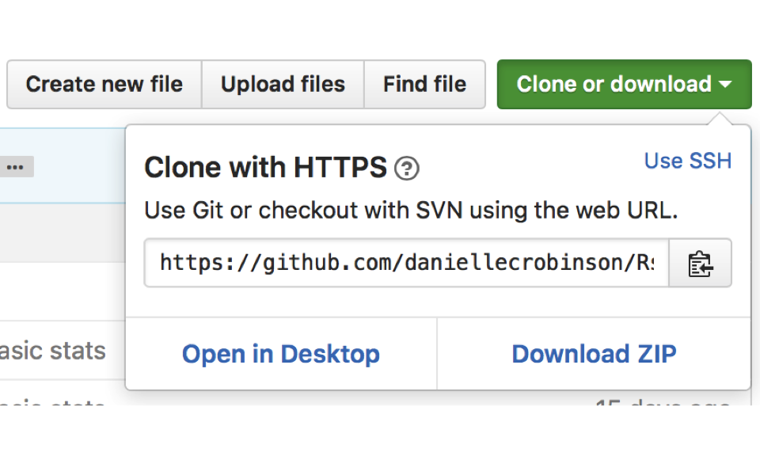

- Click on “Clone or Download”
- Click on “Download Zip”

## Why should you use R??

- Free!
  - unlike Prism, excel
- Open Source
  - Tons of support, packages, tools
  - Don’t trap your file in proprietary format!
- Great for stats
  - Defaults not hidden, question assumptions

## Basics (1)

- use # to comment
- “**<-**” assigns values to a variable

```r
x<-1
x
```

```
## [1] 1
```

- = assigns a value ( x = 5)
- == assigns equality (a == b)
- functions ()

```r
print(x)
```

```
## [1] 1
```

## Basics (2)

- help() and ?
- in R console, use up arrow to re-type what you just wrote
- variable names can’t start with a number
  - eg Data1 not 1Data
- throwing errors is normal! You will create errors *a lot*
- when you need to install package:
  - install.packages(“png”)

### R is *stupid* and only knows what *you* input

## This is what R Studio looks like:

[figure not shown]

## Resources

- CRAN: https://cran.r-project.org
- http://stackoverflow.com - like google for coding questions
- R Markdown cheat sheets (rmarkdown.rstudio.com)
- Ted Laderas’ R bootcamp: https://github.com/laderast/r-bootcamp
- Mozilla study groups: https://github.com/mozillascience/studyGroupLessons/issues
- R Open Sci (https://ropensci.org)
- R meetup groups (https://www.meetup.com/portland-r-user-group/)
- cookbook-r.com
- tidyverse
- Hadley Wickham (https://en.wikipedia.org/wiki/Hadley_Wickham)
- additional plotting abilities with ggplot package (we’re not going into this)

## Fun Events: cascadiarconf.com

[figure not shown]

## Fun Events: Science Hack Day PDX!

- http://portland.sciencehackday.org/
- Join us on Slack! pdxscience.slack.com

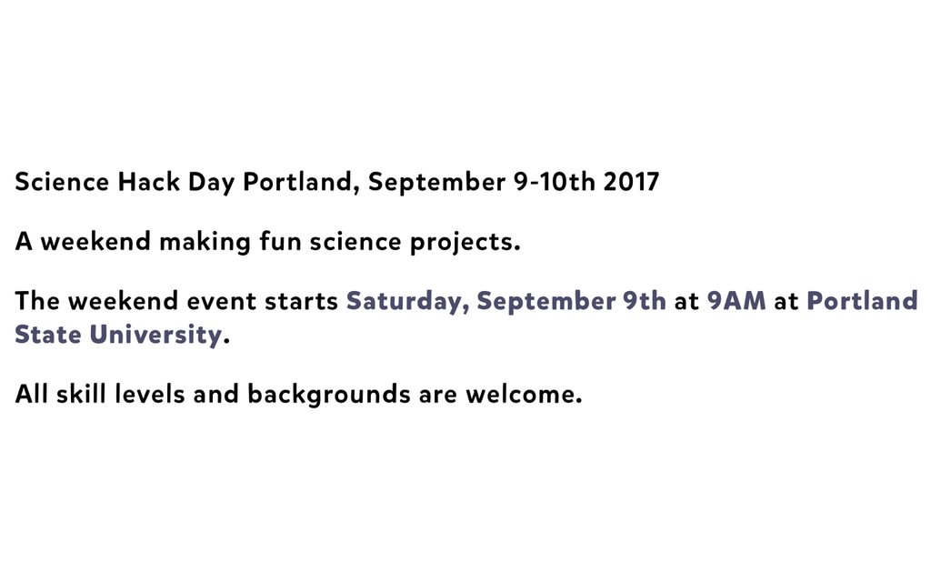

## Fun Events: BioData Club

- https://biodata-club.github.io/

[figure not shown]

- Join us on Slack! biodata-club.slack.com

## Let’s go!

From the Github downloaded files, open:

- “example_lengths_for_R.csv”
- “BasicStatsCode.pdf”

We’ll start with “BasicStatsCode.pdf”

### *PLEASE ASK US IF YOU ARE CONFUSED! :-)*

Use your **yellow** sticky note for “confused” and **green** for “ok”